# Lab7

### 19BCE1560

### 20th September, 2021

## Index

Click to go to the respective Question  
1. Question 1  
2. Question 2  
3. Question 3  
4. Question 4

## Question 1

Q. In the realtime data available on European Exports, identify the total Export Volume in tonnes. Find the percentage exported from India

```r
data=read.csv("EuropeanImportsFromOtherCountries.csv",stringsAsFactors = FALSE)
head(data,1)
```

```
##   Year ExportCountry ImportCountry         Class
## 1 2018   Afghanistan   Netherlands Other primary
##                               Category  CNcode
## 1 Vegetables, fresh, chilled and dried 7039000
##                                                                                    Description
## 1  Leeks and other alliaceous vegetables, fresh or chilled (excl. onions, shallots and garlic)
##   Crop Volume
## 1           0
```

```r
data$Volume=as.numeric(gsub(",","",data$Volume))
totalImports=sum(data$Volume)
totalImports
```

```
## [1] 8353407
```

Total imports are thus seen above.

```r
ind=sum(data[data$ExportCountry=="India",]$Volume)
#ind
(ind/totalImports)*100
```

```
## [1] 5.328652
```

## Question 2

Q. Plot the percentage export volume of all the countries which exceed 5%. Find the global rank of India in exporting products to Europe.

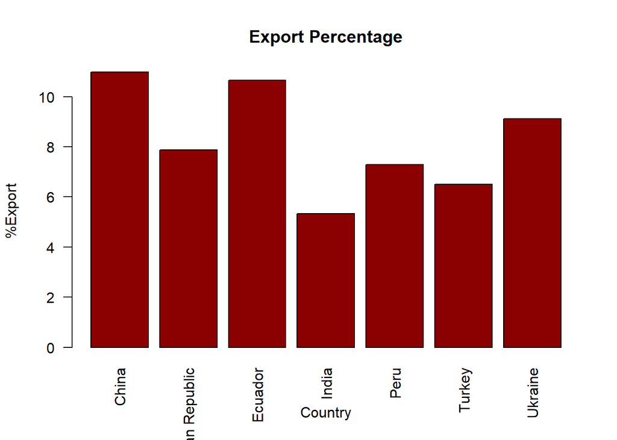

```r
library(data.table)
globtab = data.table(data$ExportCountry,data$Crop,data$Volume)
names(globtab)=c("ExportCountry","Crop","Volume")
globExpPer = globtab[,sum(Volume),by=ExportCountry]
names(globExpPer)=c("ExportCountry","Volume")
globExpPer$Perc=(globExpPer$Volume/totalImports)*100
barplot( globExpPer[globExpPer$Perc>5]$Perc,
        main = "Export Percentage",
        xlab = "Country",
        ylab = "%Export",
        names.arg = globExpPer[globExpPer$Perc>5]$ExportCountry,
        col = "darkred",
        horiz = FALSE,las=2)
```

Now we find rank of india. Since India is among the top exporters, we need not plot those with percentages less than 5 to find it’s rank.

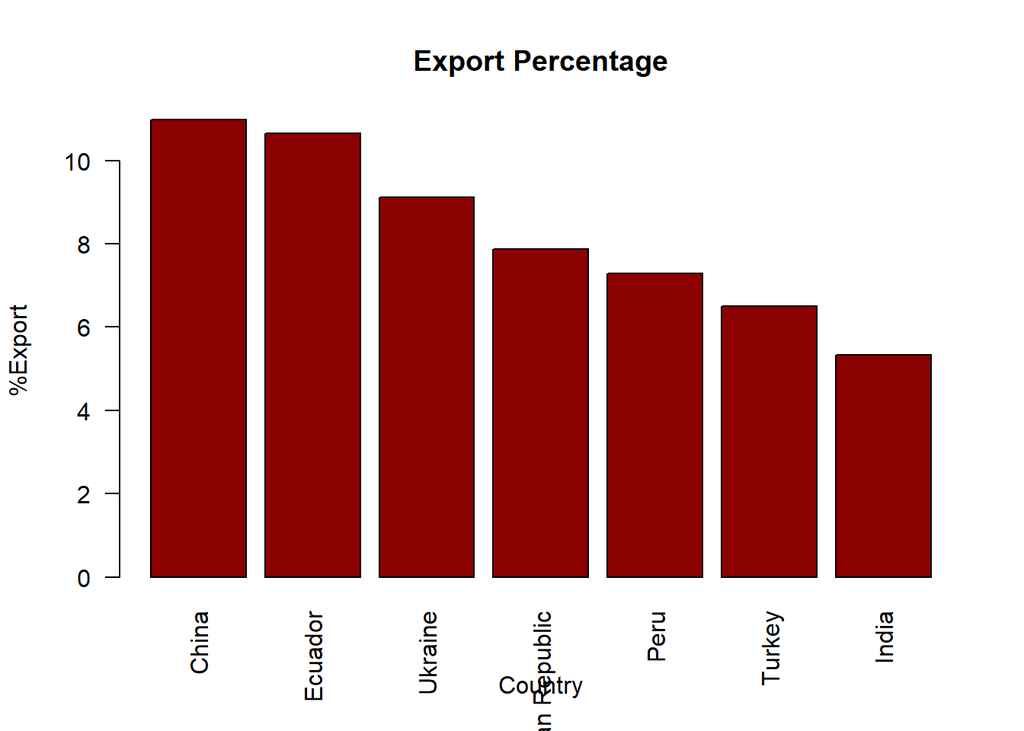

```r
globExpPer=globExpPer[order(globExpPer$Volume,decreasing=TRUE)]
barplot( globExpPer[globExpPer$Perc>5]$Perc,
        main = "Export Percentage",
        xlab = "Country",
        ylab = "%Export",
        names.arg = globExpPer[globExpPer$Perc>5]$ExportCountry,
        col = "darkred",
        horiz = FALSE,las=2)
```

Thus, we see India is 7th in the world.

## Question 3

Q. Find the first three crops having the highest exports from India. Plot their percentage export of the total exports from India.

1. Below, we see that some crop names are not available in the dataset. So, We shall not be including that while finding the top crops exported from India.

```r
topcrop=globtab[globtab$ExportCountry=="India",]
top=topcrop[,sum(Volume), by=Crop]
names(top)=c("Crop","Volume")
top=top[order(top$Volume,decreasing = TRUE)]
totalImports=sum(top$Volume)
top
```

```
##                    Crop Volume
##  1:                     388715
##  2:      Soya bean seed  15508
##  3:           Soyabeans  15090
##  4:   WhiteSugsr>99%suc   9627
##  5:       OilCake Solid   3614
##  6:        Cane or beet   2778
##  7:      Soyabean flour   2071
##  8:          WhiteSugar   2022
##  9:                Cane    908
## 10:            Raw cane    800
## 11: decafeneitted coffe    718
## 12:             Linseed    640
## 13:             Sesamum    618
## 14:            Oil cake    599
## 15:         Guava Mango    396
## 16:     long grain rice    284
## 17:              Coffee    247
## 18:             Cereals    207
## 19:          Vegetables    143
## 20:              Spices    106
## 21:         Cashew nuts     32
## 22:            coconuts      1
##                    Crop Volume
```

Soya bean seed takes the lead, Then soya beans and white sugar.

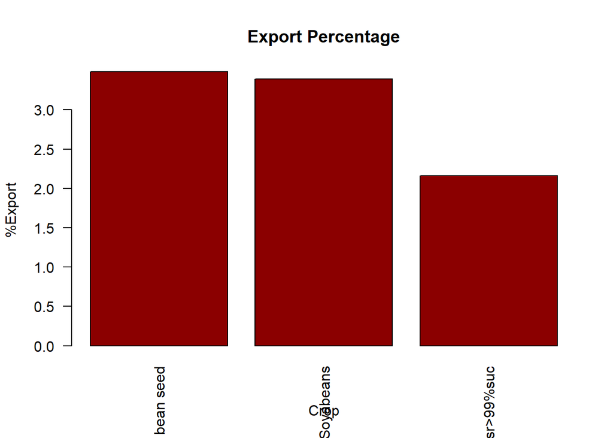

```r
topp=top[1:4,]
topp$perc=(topp$Volume/totalImports)*100
barplot( topp[topp$Crop!="",]$perc,
        main = "Export Percentage",
        xlab = "Crop",
        ylab = "%Export",
        names.arg = topp[topp$Crop!="",]$Crop,
        col = "darkred",
        horiz = FALSE,las=2)
```

## Question 4

Q. Plot the percentage of the class of different crops exported from India.

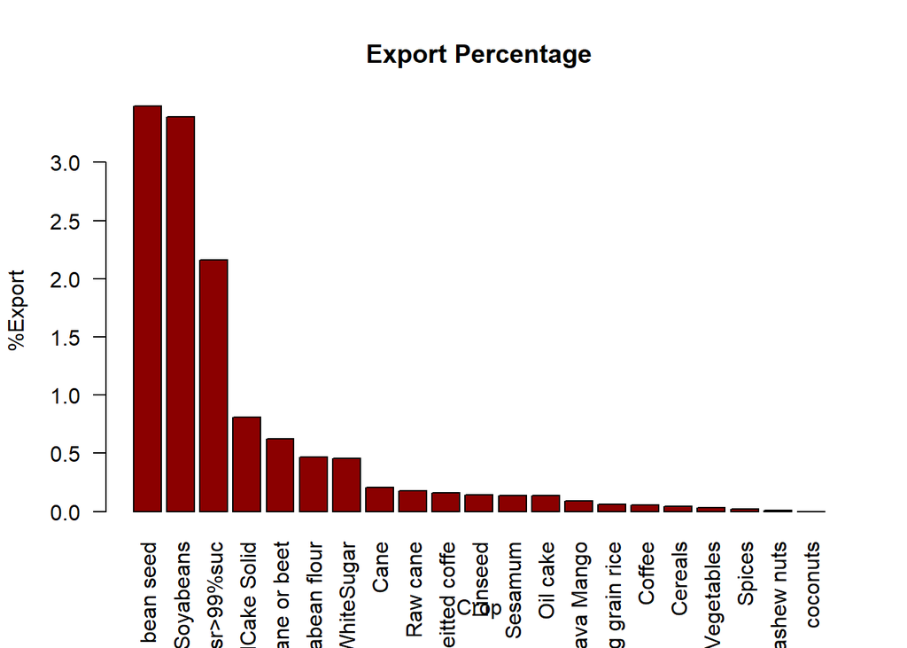

```r
top$perc=(top$Volume/totalImports)*100
barplot( top[top$Crop!="",]$perc,
        main = "Export Percentage",
        xlab = "Crop",
        ylab = "%Export",
        names.arg = top[top$Crop!="",]$Crop,
        col = "darkred",
        horiz = FALSE,las=2)
```